# Ghod Sub-basin CFRA Forest Selection

Elisa Stefaniak

2025-02-24

## The Problem

In this document I describe the process of generating afforestation maps for the Bhima Upper Basin Ghod Sub-basin. First we examine the Ghod Sub-basin and it’s current afforestation.

Load Ghod Sub-basin region

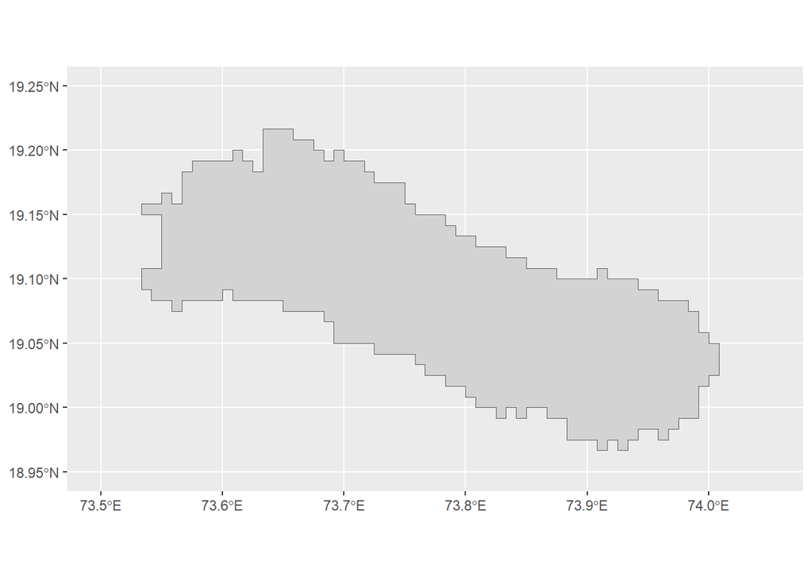

```r
data_gpkg_region <- sf::read_sf("../data/maps/region.gpkg")
data_gpkg_region_2d <- st_zm(data_gpkg_region$geom)

ggplot() +
  geom_sf(data = data_gpkg_region_2d, fill = "lightgrey") +
  # geom_sf(data = data_gpkg_2d, fill = "grey") +
  # geom_sf(data = data_gpkg_intersected_2d, fill = "forestgreen") +
  # geom_sf(data = data_gpkg_intersected_out_2d, fill = "lightgreen") +
  scale_x_continuous(limits = c(73.5, 74.05)) +
  scale_y_continuous(limits = c(18.95, 19.25))
```

Total size of the Ghod Sub-basin region is 628038265.853479 m2.

Get current aforestation (raster), subset to just forests and convert to shapes. This is done in a separate code file (`code/create_current_forest_polygons.R`) as the process is computing-intensive.

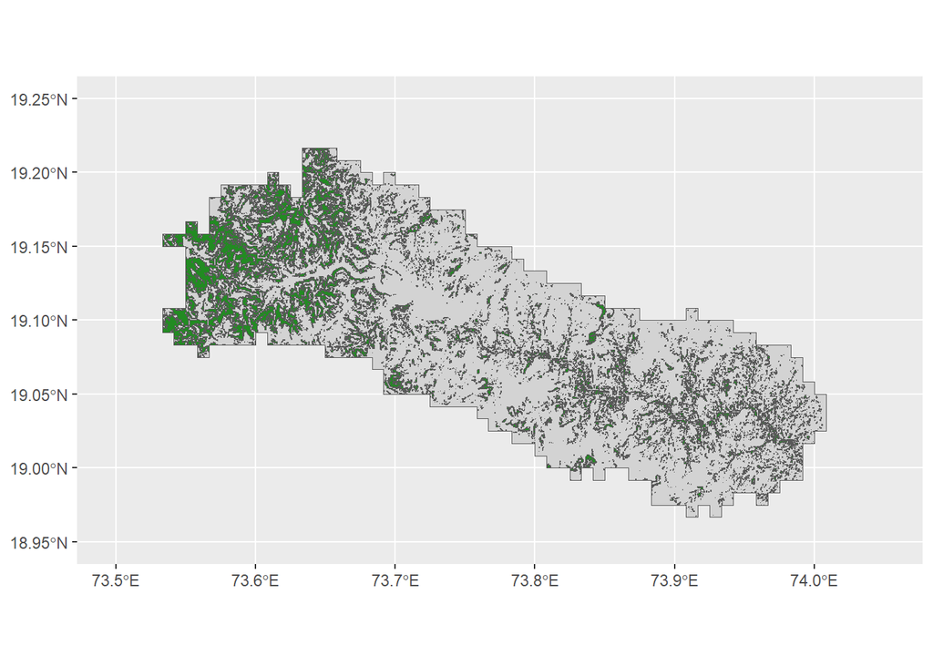

```r
useclass_gpkg <- rast("../data/maps/land_use_classes.tif")

## Forest area is under 0 so we make everything else NA
current_forest2 <- sf::read_sf("../out/current_forest.shp")

ggplot() +
  geom_sf(data = data_gpkg_region_2d, fill = "lightgrey") +
  geom_sf(data = current_forest2, fill = "forestgreen", lwd = 0) +
  # geom_tile(data = clipped_raster_df, aes(x = x, y = y, fill = "landsurface/land_use_classes")) +
  scale_x_continuous(limits = c(73.5, 74.05)) +
  scale_y_continuous(limits = c(18.95, 19.25)) +
  guides(fill="none")
```

Current afforestation is 111089569.672363 m2 which is: 17.6883441204647% of the total area of the subbasin.

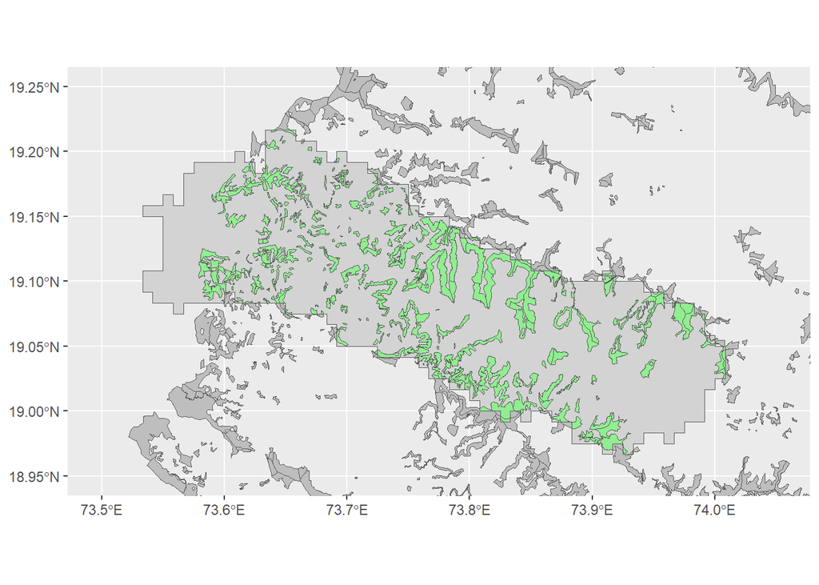

```r
data_gpkg <- sf::read_sf("../data/maps/junnar_potential_CFR.gpkg")
data_gpkg_2d <- st_zm(data_gpkg$geom)

# Extract forests only in modelled area

intersected_CFRS <- st_intersects(data_gpkg_region_2d, data_gpkg_2d)

data_gpkg_intersected_2d <- data_gpkg_2d[intersected_CFRS[[1]]]
data_gpkg_intersected_out_2d <- st_intersection(data_gpkg_region_2d, data_gpkg_2d)

ggplot() +
  geom_sf(data = data_gpkg_region_2d, fill = "lightgrey") +
  geom_sf(data = data_gpkg_2d, fill = "grey") +
  # geom_sf(data = data_gpkg_intersected_2d, fill = "forestgreen") +
  geom_sf(data = data_gpkg_intersected_out_2d, fill = "lightgreen") +
  scale_x_continuous(limits = c(73.5, 74.05)) +
  scale_y_continuous(limits = c(18.95, 19.25))
```

The total potential new aforested area is 118047584.209526 m2 which is: 18.7962407114006% of the total area of the subbasin. The maximum aforestation we would get in the basin is therefore: 36.4845848318653%.

If we include now also the original forests we get:

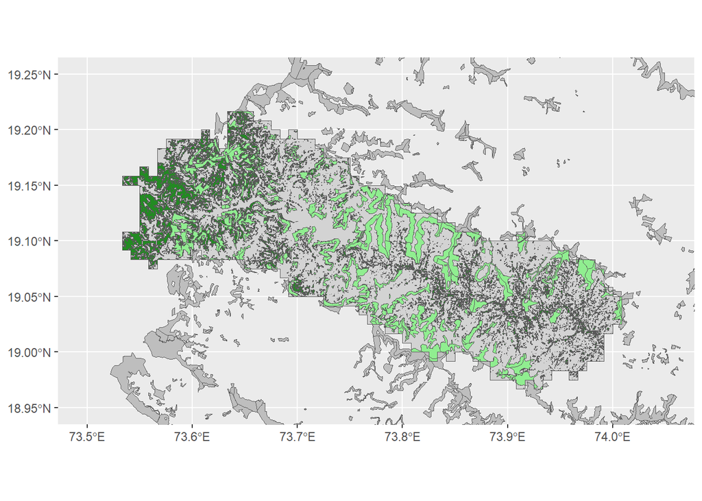

```r
ggplot() +
  geom_sf(data = data_gpkg_region_2d, fill = "lightgrey") +
  geom_sf(data = data_gpkg_2d, fill = "grey") +
  geom_sf(data = current_forest2, fill = "forestgreen", lwd = 0) +
  # geom_sf(data = data_gpkg_intersected_2d, fill = "forestgreen") +
  geom_sf(data = data_gpkg_intersected_out_2d, fill = "lightgreen") +
  scale_x_continuous(limits = c(73.5, 74.05)) +
  scale_y_continuous(limits = c(18.95, 19.25))
```

## Random subsetting of CFRA forests

We want to look at 0-100%. Below I create a code to get 50% of the plots.

```r
forest_areas <- st_area(data_gpkg_intersected_out_2d)
total_area = sum(forest_areas)

area_percentage = 0.5
total_area_aim = total_area * area_percentage

forest_areas_perm_ind <- permute(1:length(forest_areas))
forest_areas_perm <- forest_areas[forest_areas_perm_ind]
forest_areas_perm_cumsum <- cumsum(forest_areas_perm)
ind_out <- forest_areas_perm_ind[forest_areas_perm_cumsum <= total_area_aim]

data_gpkg_intersected_out_2d_subset <- data_gpkg_intersected_out_2d[ind_out]

sum(st_area(data_gpkg_intersected_out_2d_subset)) / 10000
```

```
## 5898.12 [m^2]
```

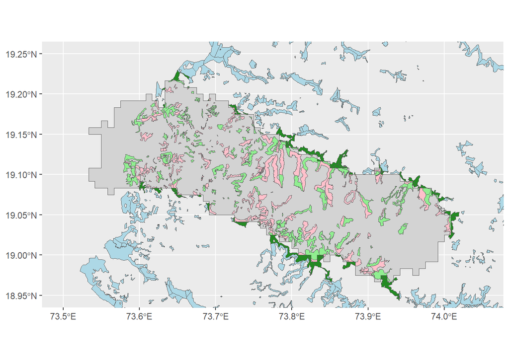

```r
ggplot() +
  geom_sf(data = data_gpkg_region_2d, fill = "lightgrey") +
  geom_sf(data = data_gpkg_2d, fill = "lightblue") +
  geom_sf(data = data_gpkg_intersected_2d, fill = "forestgreen") +
  geom_sf(data = data_gpkg_intersected_out_2d, fill = "lightgreen") +
  geom_sf(data = data_gpkg_intersected_out_2d_subset, fill = "pink") +
  scale_x_continuous(limits = c(73.5, 74.05)) +
  scale_y_continuous(limits = c(18.95, 19.25))
```

I repeat this for 20, 40, 60 and 80% and save the outputs (executed offline).

```r
area_percentage_aim = c(0.2, 0.4, 0.6, 0.8, 1.0)
names_file = c("02", "04", "06", "08", "1")
total_area_aim = total_area * area_percentage_aim

lapply(1:5, function(x){
  ind_out <- forest_areas_perm_ind[forest_areas_perm_cumsum <= total_area_aim[x]]
  data_gpkg_intersected_out_2d_subset <- data_gpkg_intersected_out_2d[ind_out]
  st_write(data_gpkg_intersected_out_2d_subset, paste0(c("../out/forest_", names_file[x], ".gpkg"), collapse = ""))
})
```

Plotting the potential areas for each afforestation scenario. The pink areas correspond to the areas selected for afforestation, and the bright green are the remainder of the potential areas for reforestation. The dark greay are the current forest areas.

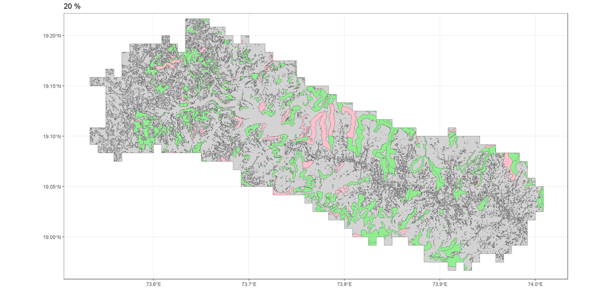

```r
data_gpkg_forest_02 <- sf::read_sf("../out/forest_02.gpkg")
forest_02 <- st_zm(data_gpkg_forest_02$geom)

data_gpkg_forest_04 <- sf::read_sf("../out/forest_04.gpkg")
forest_04 <- st_zm(data_gpkg_forest_04$geom)

data_gpkg_forest_06 <- sf::read_sf("../out/forest_06.gpkg")
forest_06 <- st_zm(data_gpkg_forest_06$geom)

data_gpkg_forest_08 <- sf::read_sf("../out/forest_08.gpkg")
forest_08 <- st_zm(data_gpkg_forest_08$geom)

data_gpkg_forest_1 <- sf::read_sf("../out/forest_1.gpkg")
forest_1 <- st_zm(data_gpkg_forest_1$geom)


plot_02 <- ggplot() +
  geom_sf(data = data_gpkg_region_2d, fill = "lightgrey") +
  geom_sf(data = current_forest2, fill = "forestgreen", alpha = 0) +
  geom_sf(data = data_gpkg_intersected_out_2d, fill= "lightgreen") +
  geom_sf(data = forest_02, fill = "pink") +
  scale_x_continuous(limits = c(73.53, 74.01)) +
  scale_y_continuous(limits = c(18.97, 19.21)) +
  labs(title = "20 %", hjust = 0.5)+
  theme(plot.title = element_text(hjust = 0.5))+
  theme_bw()

plot_04 <- ggplot() +
  geom_sf(data = data_gpkg_region_2d, fill = "lightgrey") +
  geom_sf(data = current_forest2, fill = "forestgreen", alpha = 0) +
  geom_sf(data = data_gpkg_intersected_out_2d, fill= "lightgreen") +
  geom_sf(data = forest_04, fill = "pink") +
  scale_x_continuous(limits = c(73.53, 74.01)) +
  scale_y_continuous(limits = c(18.97, 19.21)) +
  labs(title = "40 %", hjust = 0.5)+
  theme(plot.title = element_text(hjust = 0.5))+
  theme_bw()

plot_06 <- ggplot() +
  geom_sf(data = data_gpkg_region_2d, fill = "lightgrey") +
  geom_sf(data = current_forest2, fill = "forestgreen", alpha = 0) +
  geom_sf(data = data_gpkg_intersected_out_2d, fill= "lightgreen") +
  geom_sf(data = forest_06, fill = "pink") +
  scale_x_continuous(limits = c(73.53, 74.01)) +
  scale_y_continuous(limits = c(18.97, 19.21)) +
  labs(title = "60 %", hjust = 0.5)+
  theme(plot.title = element_text(hjust = 0.5))+
  theme_bw()

plot_08 <- ggplot() +
  geom_sf(data = data_gpkg_region_2d, fill = "lightgrey") +
  geom_sf(data = current_forest2, fill = "forestgreen", alpha = 0) +
  geom_sf(data = data_gpkg_intersected_out_2d, fill= "lightgreen") +
  geom_sf(data = forest_08, fill = "pink") +
  scale_x_continuous(limits = c(73.53, 74.01)) +
  scale_y_continuous(limits = c(18.97, 19.21)) +
  labs(title = "80 %", hjust = 0.5)+
  theme(plot.title = element_text(hjust = 0.5))+
  theme_bw()

plot_1 <- ggplot() +
  geom_sf(data = data_gpkg_region_2d, fill = "lightgrey") +
  geom_sf(data = current_forest2, fill = "forestgreen", alpha = 0) +
  geom_sf(data = data_gpkg_intersected_out_2d, fill= "lightgreen") +
  geom_sf(data = forest_1, fill = "pink") +
  scale_x_continuous(limits = c(73.53, 74.01)) +
  scale_y_continuous(limits = c(18.97, 19.21)) +
  labs(title = "100 %", hjust = 0.5)+
  theme(plot.title = element_text(hjust = 0.5))+
  theme_bw()


afforestation_plots <- ggarrange(plot_02, plot_04, plot_06, plot_08, plot_1,
                                       ncol = 2, nrow = 3)

# ggsave(plot = afforestation_plots, filename = "../out/plots/afforestation_maps.png",
#        height = 8.06, width = 9.73)

plot_02
```

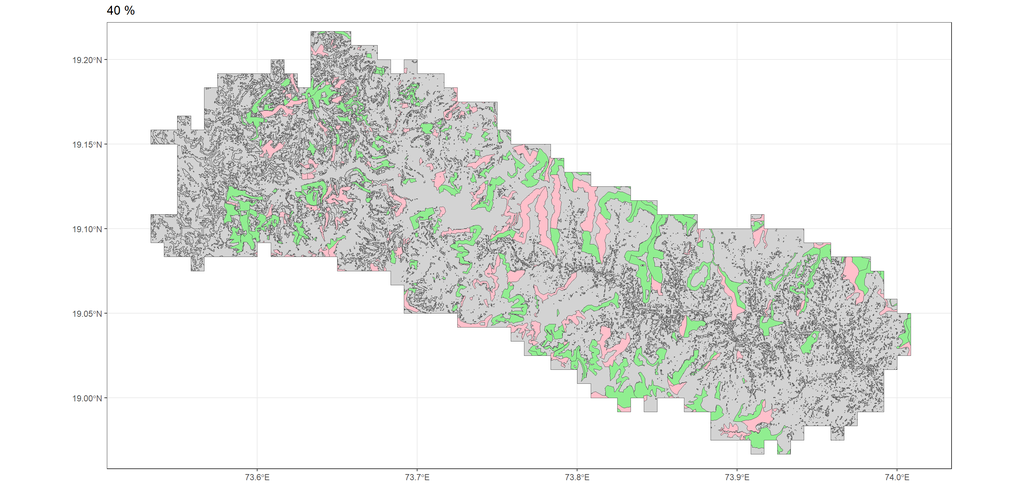

```r
plot_04
```

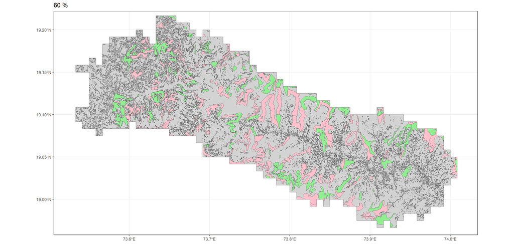

```r
plot_06
```

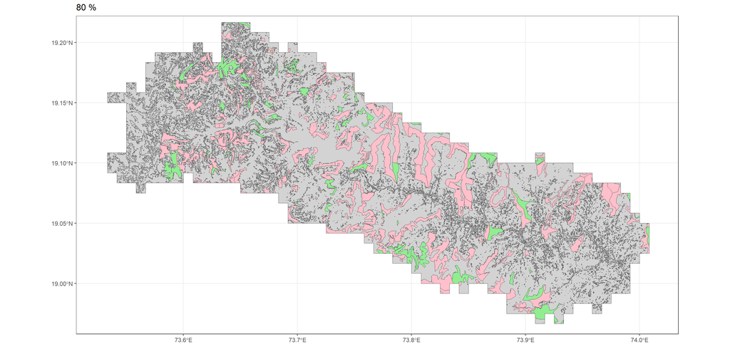

```r
plot_08
```

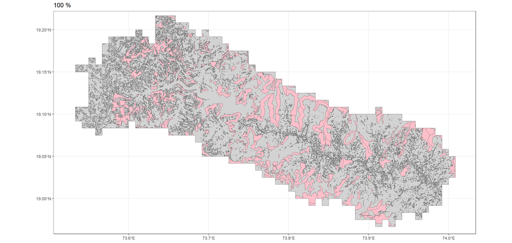

```r
plot_1
```

```r
# ggsave(plot = plot_1, filename = "../out/plots/map_basin.png",
#        height = 5.31, width = 6.43)
```

## Prioritised subsetting of CFRA forests

For each potential area for afforestation, we calculate the distance to the closest current forest.

```r
# # for each potential area, calculate the distance to the closest current forest
# m_to_forest0 <- lapply(1:length(data_gpkg_intersected_out_2d), function(x){
#       distance_to_forest <- st_distance(data_gpkg_intersected_out_2d[x], st_union(current_forest2))
#     })
# saveRDS(m_to_forest0, "../out/m_to_forest0.rds")

# read RDS (output from code above)
m_to_forest0 <- readRDS("../out/m_to_forest0.rds")

#save only the distance to nearest forest
m_to_forest <- lapply(1:length(data_gpkg_intersected_out_2d), function(x){
  m_to_forest0[[x]][1]
})

# turn into a data frame
m_to_forest_df0 <- do.call(rbind.data.frame, m_to_forest)
colnames(m_to_forest_df0) <- "distance_m"

# add an index based on order of distance

m_to_forest_df <- m_to_forest_df0 %>%
  mutate(position = row_number(-distance_m))

table(m_to_forest_df$distance_m)
```

```
##
##                0 3.00142468417644 4.13998931095657 5.17639021852526
##              290                1                1                1
## 10.8580757127483 12.0877421833192 13.3998554002739 13.5356120584885
##                1                1                1                1
## 22.9319701010667 22.9672886268341 26.5726631126516 26.7188846618845
##                1                1                1                1
## 27.1349514437901  28.916340487596  30.926741360087 35.7930503143407
##                1                1                1                1
## 40.4808136069662 41.6695766723689 42.6374646450138 47.3015858226756
##                1                1                1                1
## 52.7846217310297 63.0043726075988 68.2534928479308 69.3104537734899
##                1                1                1                1
##  75.647615945009 80.2422678899154 119.522676810017 125.810756457273
##                1                1                1                1
## 138.016078252174 169.666865329673 180.696428420477 186.983957400317
##                1                1                1                1
## 189.934323726356 206.499030203407 245.080529842987 277.240742636478
##                1                1                1                1
## 287.121504510957 333.287922543443  402.33838391021 424.843366862549
##                1                1                1                1
## 442.710263785281 494.839644977163 520.703816091484 554.347463078944
##                1                1                1                1
```

Above, we see that 290 out of 333 polygons of potential afforestation locations are 0 meters away from current forest cells, and the maximum distance is around 550 meters away. We have thus decided to randomly assign polygons for the afforestation scenarios.

```r
# st_write(data_gpkg_region, "../data/maps/region.shp")
```